**Burhan Hajee's** Portfolio

- [LinkedIn](https://www.linkedin.com/in/burhanhajee/)
- [GitHub](https://github.com/burhanhajee)

# Employee Attrition: A Comprehensive Data Exploration

### Introduction

In the current business milieu, where fluctuations in employee strength significantly affect a company's operations, it's crucial to gain insights into employee attrition. This initiative undertakes an in-depth analysis of the data concerning employees leaving, aiming to unearth pivotal patterns and insights crucial for workforce stability.

### Objectives

- Identifying Key Influencers: Our main thrust is on pinpointing the pivotal factors leading to employee exits. We scrutinize various elements like job roles, departmental dynamics, the equilibrium between work and personal life, tenure in the organisation, etc., to understand their bearing on staff departures.
- Comparative Evaluation: The project incorporates a comparative assessment of different employee characteristics, including age, educational background, job contentment, and earnings. The objective is to discern the distinctions in these aspects between employees who stay aboard and those who part ways with the organisation.
- Department-Specific Insights: By analysing attrition rates across diverse departments, we intend to detect department-specific trends, thereby providing valuable insights for bespoke HR strategies.
- Exploring Predictive Indicators: Our endeavour is to identify potential indicators that might foresee attrition, enabling organisations to proactively tackle factors leading to high staff turnover.

This endeavour is an invaluable asset for HR professionals, organisational leaders, and decision-makers, offering them profound insights into employee attrition. By pinpointing the undercurrents of turnover, it furnishes essential insights for developing strategies aimed at enhancing employee retention, boosting job satisfaction, and fostering a stable, efficacious workplace atmosphere.

In essence, this project leverages data analytics and visualisation to transform complex employee data into actionable insights, assisting organisations in informed decision-making regarding their human resource management.

#### Data Origins:

The data for this analysis comes from Kaggle, a renowned hub for data science challenges and datasets. We specifically use the IBM HR Analytics Employee Attrition & Performance dataset, which sheds light on the intricacies of employee turnover.

#### Data Overview:

Sample Scope: Our dataset includes information on 1,470 employees, making it a robust base for our study. It comprises 35 distinct variables, offering a broad perspective on employee traits and situations. The 'Attrition' variable stands out in this dataset. It's a binary indicator showing if an employee has exited the company ('Yes' or 'No'). This forms the central focus of our analysis.

#### Quantitative and Qualitative Attributes

This includes both continuous and discrete figures like 'Age', 'DailyRate', 'DistanceFromHome', 'HourlyRate', 'MonthlyIncome', 'MonthlyRate', 'TotalWorkingYears', 'YearsAtCompany', 'YearsInCurrentRole', 'YearsSinceLastPromotion', and 'YearsWithCurrManager'. The categorical aspects include 'Attrition', 'BusinessTravel', 'Department', 'EducationField', 'Gender', 'JobRole', 'MaritalStatus', 'OverTime', and more.

#### Principal Employee Factors: The dataset covers a range of attributes like demographic information (age, gender, marital status), job-related features (role, department, working conditions), and career history (tenure at the company, promotion history, role transitions).

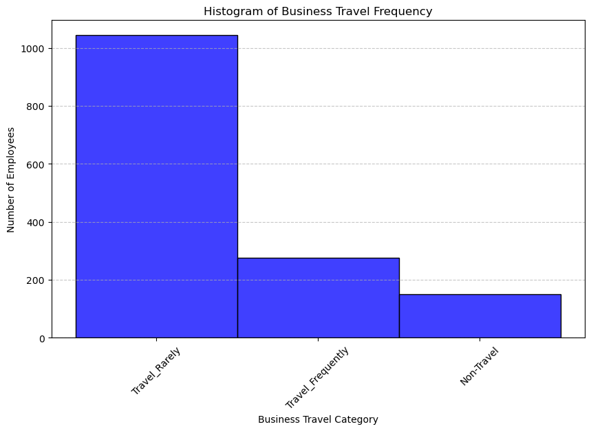

The histogram illustrates work-related travel patterns among office employees. The majority fall into the 'Travel_Rarely' category, indicating infrequent business trips. A smaller group, 'Non-Travel,' never travels for work. The 'Travel_Frequently' group represents those who travel more often but not constantly. In essence, most employees do not regularly travel for work, with variations in travel frequency among them.

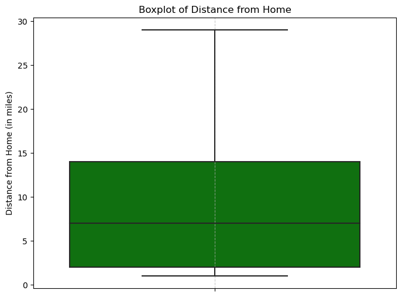

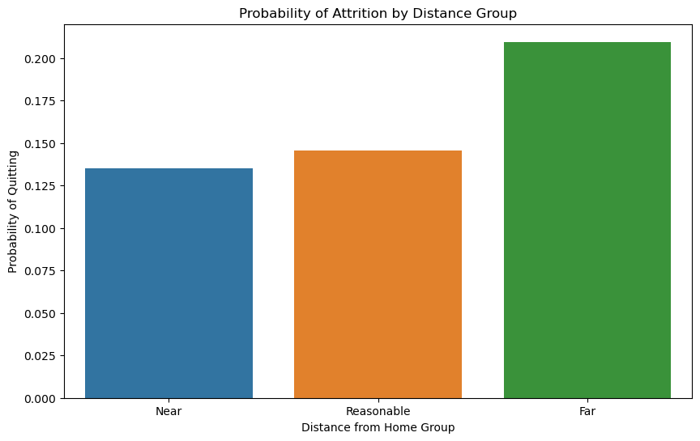

Longer commutes are often associated with higher levels of employee turnover due to the added stress and time consumed by longer distances traveled - This finding is aligned with common intuitions and existing literature on the subject. The increasing trend from 'Near' to 'Far' suggests a potential relationship between distance and attrition that would be worth investigating further, possibly with additional context or data to understand any confounding factors or the causality of this relationship.

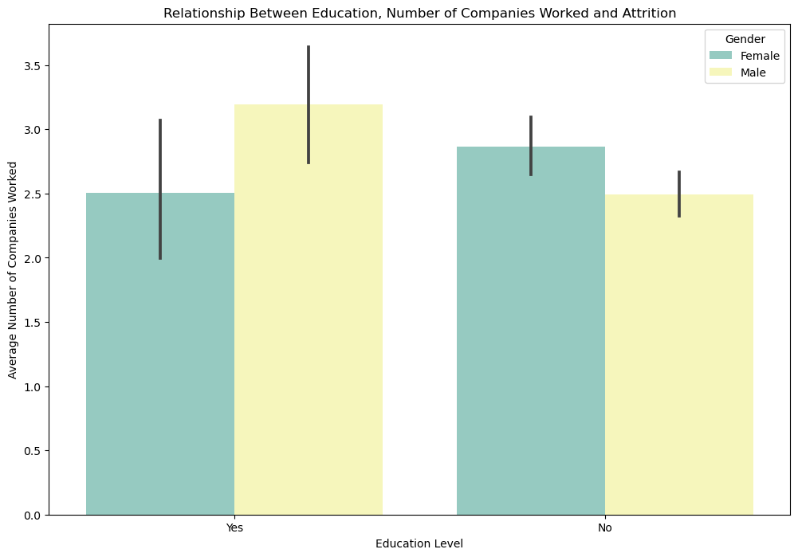

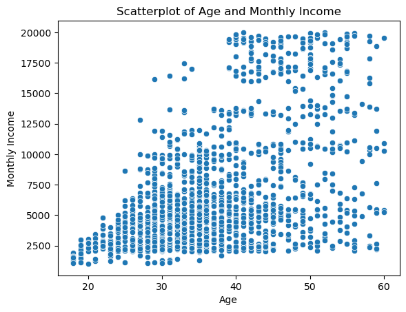

The data analysis reveals several key observations regarding the relationship between age and monthly income. Firstly, there is a consistent positive correlation, indicating that as age increases, monthly income tends to rise. However, the concentration of data points is notably higher at the lower end of the income spectrum, suggesting that a significant portion of individuals earns lower salaries regardless of age. Additionally, there is considerable income variation within each age group, despite there being a ceiling limit on income potential between 20-30 years old, 30-40 years old and 40+ years.

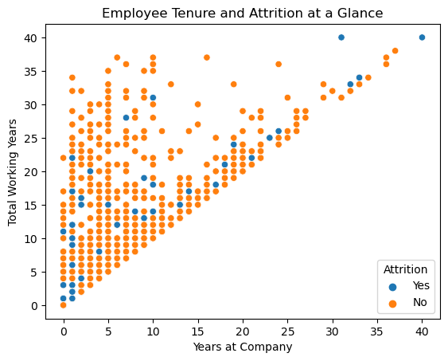

Employees are more likely to quit in the first 5 years at the company. This period may be critical for retention efforts, as it may reflect a phase where employees assess their career trajectory, satisfaction with their role, and long-term prospects within the company.

There is a less pronounced but still noticeable trend of attrition among employees who have predominantly worked at one company for the majority of their careers. This could be due to various life stage changes, such as nearing retirement, desire for a career shift, or organizational changes that may disproportionately affect long-term employees.

### Random Forest to Predict Attrition using GridSearchCV for Hypertuning

Random Forest is a powerful and versatile machine learning algorithm that is well-suited for classification problems like predicting employee attrition. Here are the reasons why Random Forest might be chosen for this data:

- Handling of Complex Interactions: Random Forest can capture complex interactions between features without the need for feature engineering. It is capable of handling non-linear relationships which might be present in the data.
- Feature Importance: Random Forest provides insights into which features are most important for making predictions. This is particularly useful in understanding the factors contributing to attrition.

In the context of predicting attrition, these properties allow Random Forest to model the probability of an employee leaving the company based on a set of explanatory variables, such as job role, marital status, overtime, age, etc., while providing a clear indication of the relative importance of each feature.

GridSearchCV systematically tries various combinations of hyperparameters for a given machine learning model, evaluating each combination using cross-validation to determine which set of parameters yields the best performance. Its goal is to automate the process of hyperparameter tuning, ensuring that the selected model is as optimized as possible for the given task.

```
{'max_depth': 10,
                 'max_features': 'auto',
                 'min_samples_leaf': 2,
                 'min_samples_split': 2,
                 'n_estimators': 100}
```

```
{Accuracy: 0.8639455782312925
  Confusion Matrix:
   [[376   4]
   [ 56   5]]
  Classification Report:
                 precision    recall  f1-score   support

             0       0.87      0.99      0.93       380
             1       0.56      0.08      0.14        61

      accuracy                           0.86       441
     macro avg       0.71      0.54      0.53       441
  weighted avg       0.83      0.86      0.82       441}
```

#### Interpretation of Results

The classification report provides precision, recall, and F1-scores for each class. For the 'no attrition' class (0), the model achieved high precision (0.87) and recall (0.99), resulting in a high F1-score (0.93), indicating strong performance for this class. However, for the 'attrition' class (1), the precision drops to 0.56, and the recall is quite low at 0.08, leading to a much lower F1-score of 0.14. This suggests that while the model is effective at identifying employees who do not leave the company, it struggles to correctly identify those who do, leading to many false negatives and a lower ability to correctly predict actual cases of attrition. The weighted averages indicate that the model's overall performance is skewed towards the majority class (those not leaving), which is common in imbalanced datasets.

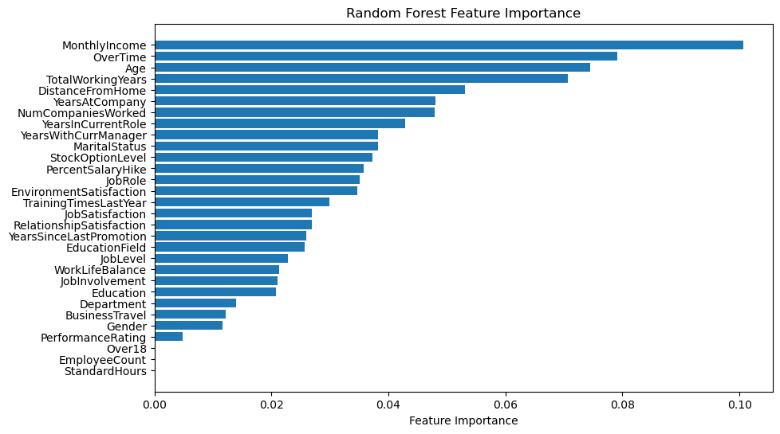

The insights from the model's feature importance rankings suggest that an employee's monthly income is the most crucial factor in predicting attrition, indicating that financial considerations play a significant role in employee retention. Following closely is the variable "OverTime," indicating that the amount of overtime an employee works can also strongly influence attrition rates. This suggests that issues related to workload and work-life balance are essential considerations for organizations aiming to reduce attrition. Additionally, the model highlights age as the third most significant feature, suggesting that there might be age-related trends in attrition, but the specifics would require further exploration.

The results of the Random Forest model indicate that it is very good at predicting employees who will stay with the company, but it has a high number of False Negatives, meaning that it often misses identifying employees who are likely to leave. Given this, the model can be used as a tool for initial screening to identify a subset of employees who are at low risk of attrition. This can help the HR department to efficiently allocate resources and focus their retention strategies on the remaining employees who are not flagged by the model as low risk. However, due to the high number of False Negatives, the model should not be used as the sole decision-making tool for identifying at-risk employees as it could lead to a false sense of security and potential neglect of individuals who are actually likely to leave but were not flagged by the model.

For interventions or policy changes aimed at reducing employee turnover, the model's insights into feature importances can be valuable. For instance, factors such as 'MonthlyIncome' and 'OverTime', which were identified as highly important for predicting attrition, can be areas of focus for improving employee satisfaction and retention. Yet, due to the model's tendency to miss actual attrition cases, it should be complemented with other HR strategies and perhaps qualitative assessments like interviews or surveys. This multifaceted approach would help in mitigating the risk of overlooking dissatisfied employees and enable the organization to address the underlying causes of attrition more comprehensively.